# Historical Forecast

```r
library(nixtlar)
```

## 1. TimeGPT Historical Forecast

When generating a forecast, sometimes you might be interested in forecasting the historical observations. These predictions, known as **fitted values**, can help you better understand and evaluate a model’s performance over time.

## 2. Load data

```r
df <- nixtlar::electricity
head(df)
```

```
#>   unique_id                  ds     y
#> 1        BE 2016-10-22 00:00:00 70.00
#> 2        BE 2016-10-22 01:00:00 37.10
#> 3        BE 2016-10-22 02:00:00 37.10
#> 4        BE 2016-10-22 03:00:00 44.75
#> 5        BE 2016-10-22 04:00:00 37.10
#> 6        BE 2016-10-22 05:00:00 35.61
```

## 3. Forecast historical data

To generate a forecast for the historical data, use `nixtlar::nixtla_client_historic`. The key parameters of this method are:

- **df**: The dataframe or `tsibble` with the time series data. It should include at least a column with the datestamps and a column with the observations. Default names for these columns are `ds` and `y`. If different, please specify their names.
- **id_col**: If the data contains multiple ids, as in this case, please specify the column that contains them. If working with a single series, leave it as it is by default (NULL).
- **level**: The prediction intervals for the forecast.

```r
nixtla_client_fitted_values <- nixtla_client_historic(df, id_col = "unique_id", level = c(80,95))
```

```
#> Frequency chosen: H
```

```r
head(nixtla_client_fitted_values)
```

```
#>   unique_id                  ds  TimeGPT TimeGPT-lo-80 TimeGPT-lo-95
#> 1        BE 2016-10-27 00:00:00 56.07623      13.95557     -8.341764
#> 2        BE 2016-10-27 01:00:00 52.41973      10.29907    -11.998258
#> 3        BE 2016-10-27 02:00:00 52.81474      10.69408    -11.603250
#> 4        BE 2016-10-27 03:00:00 52.59026      10.46960    -11.827729
#> 5        BE 2016-10-27 04:00:00 52.67297      10.55231    -11.745015
#> 6        BE 2016-10-27 05:00:00 54.10659      11.98593    -10.311399
#>   TimeGPT-hi-80 TimeGPT-hi-95
#> 1      98.19688      120.4942
#> 2      94.54039      116.8377
#> 3      94.93540      117.2327
#> 4      94.71092      117.0082
#> 5      94.79363      117.0910
#> 6      96.22725      118.5246
```

Notice that there are no fitted values for some of the initial observations. This is because `TimeGPT` requires a minimum number of values to generate reliable forecasts.

All the fitted values are generated using a rolling window, meaning that the fitted value for observation $T$ is generated using the first $T-1$ observations.

### 3.1 Fitted values from `nixtlar::nixtla_client_forecast`

`nixtlar::nixtla_client_historic` is the dedicated function that calls `TimeGPT`’s method for generating fitted values. However, you can also use `nixtlar::nixtla_client_forecast` with `add_history=TRUE`. This will generate both a forecast for the historical data and for the next $h$ future observations.

## 4. Plot historical forecast

`nixtlar` includes a function to plot the historical data and any output from `nixtla_client_forecast`, `nixtla_client_historic`, `nixtla_client_anomaly_detection` and `nixtla_client_cross_validation`. If you have long series, you can use `max_insample_length` to only plot the last N historical values (the forecast will always be plotted in full).

```
#> Frequency chosen: H
```

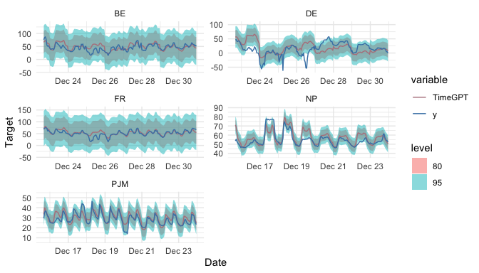

```r
nixtla_client_plot(df, nixtla_client_fitted_values, id_col = "unique_id", max_insample_length = 200)
```